# L17

# Decision Networks and Value of Information

## Decision Networks

- eg:

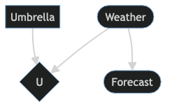

- Rectangle ≙ choice of actions
  - Umbrella node is that the agent can choose whether to take the umbrella
  - Cannot have parents
  - Act as observed evidence
- Diamond ≙ utility of the outcome
  - Depends on the action and chance nodes
  - Has to be specified as a function of all of its parents
  - Have utility values for each action instead of probabilities
- Oval ≙ chance nodes (just like BNs)
- BN but with nodes for utility and actions
- Lets us calculate the expected utility for each action
- Can be drawn as expectimax trees

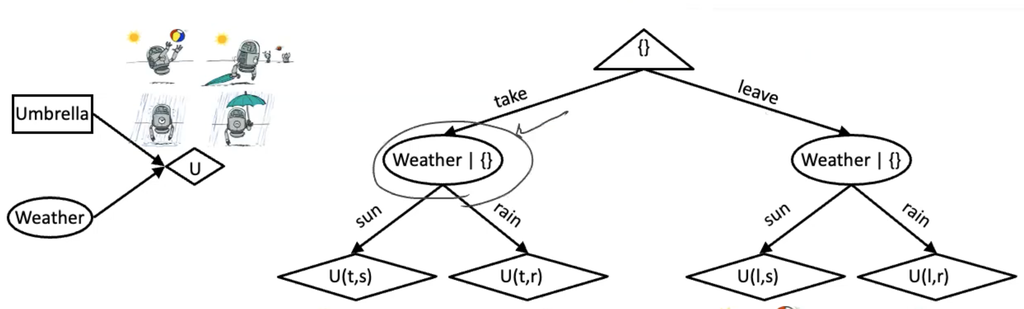

## Maximum Expected Utility (MEU)

- Choose the action which maximizes the expected utility given the evidence
- Can directly operationalize this with decision networks

[figure not shown]

- $\mathbb{EU}(\text{action})\coloneqq\sum_{\text{chance}}\mathbb{P}(\text{chance})\mathbb{U}(\text{action},\text{chance})$
  - $\mathbb{EU}(\text{leave})=\sum_{w}\mathbb{P}(w)\mathbb{U}(\text{leave},w)=0.7*100+0.3*0=70$
  - $\mathbb{EU}(\text{take})=0.7*20+0.3*70=35$
  - The $MEU$ is 70 if we leave the umbrella, so that’s the optimal decision
- $MEU(K)\coloneqq\max_{a}\mathbb{EU}(a|K)|_{K\,\coloneqq\,\{\text{knowledge}\}}$
  - $K$ can be $\varnothing$
- Have to calculate the probability of all connected chance nodes dependent on given information

### Action Selection

1. Instantiate all evidence
2. Set action node(s) each possible way
3. Calculate posterior for all parents of utility node, given the evidence
   - Use BN rules (eg variable elimination)
4. Calculate expected utility for each action
5. Choose maximizing action by calculating $MEU$s

## Value of Information

- Idea: compute value of acquiring evidence
  - Can be done directly from decision network
1. Calculate $MEU(\text{known evidence})$
2. Calculate $MEU(\text{given evidence}\,\cup\,\text{aquired evidence})$
3. $VPI(\text{aquired evidence})\coloneqq{MEU(\text{given evidence}\,\cup\,\text{aquired evidence})-MEU(\text{given evidence})}$
   - $VPI$ ≔ value price of information
   - Need to calculate a distribution only on only the given evidence as well as the corresponding $MEU$ values for each and then weight them for the $VPI$
     - This is because we don’t know the actual value, we just know that that information will be known

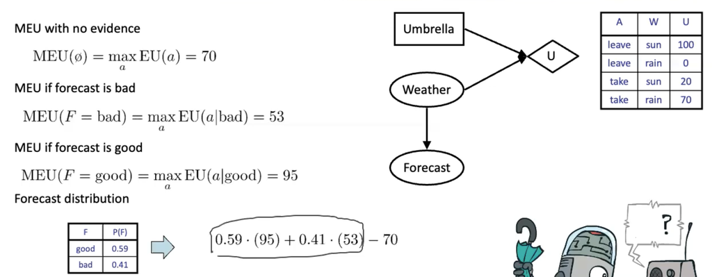

   - $$\left.VPI(E'|e)\coloneqq\left(\sum_{e'}\mathbb{P}(e'|e)MEU(e,e')\right)-MEU(e)\right|_{\begin{array}{l}
     E'\,\coloneqq\,\text{aquired evidence} \\
     e\,\coloneqq\,\text{evidence already known}
     \end{array}}$$
- eg: Prize is $0 or $100. You can play any number between 1 and 100 (chance of winning is 1%); $VPI=100-1=99$
- Nonnegative: $\forall{E',e}:VPI(E'|e)\geq{0}$
- Nonadditive: $VPI(E_{j},E_{k}|e)\,{\neq}\,VPI(E_{j}|e)+VPI(E_{k}|e)$
- Order-independent: $VPI(E_{j},E_{k}|e)=VPI(E_{j}|e)+VPI(E_{k}|e,E_{j})=VPI(E_{k}|e)+VPI(E_{j}|e,E_{k})$
- $VPI$ is 0 if the utility is independent of new information

### Value of Imperfect Information

- Can always model as a perfect indicator
- Even if something is noisy, we can model it as a perfect indicator of a guess